# The Mechanics of Data Visualization

Let’s transition away from aesthetics, and towards our third mantra:

## Use the right tool for the job.

Think back to our first chart:

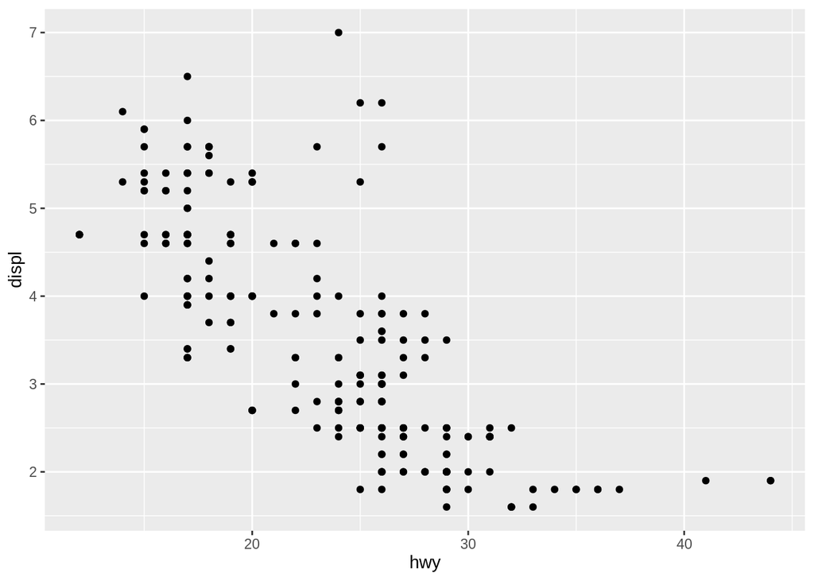

```r
ggplot(mpg, aes(hwy, displ)) +
  geom_point()
```

As you already know, this is a *scatterplot* - also known as a *point graph*. Now say we added a line of best fit to it:

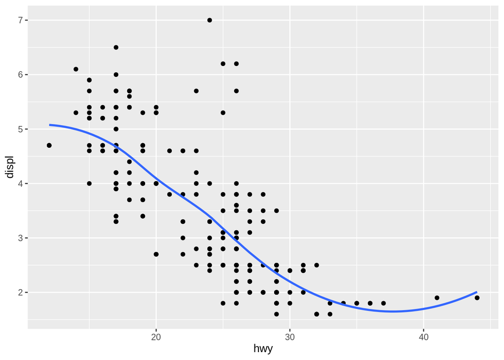

```r
ggplot(mpg, aes(hwy, displ)) +
  geom_point() +
  geom_smooth(se = F)
```

This didn’t stop being a scatterplot once we drew a line on it – but the term scatterplot no longer really encompasses everything that’s going on here. It’s also obviously not a line chart, as even though there’s a line on it, it also has points.

Rather than quibble about what type of chart this is, it’s more helpful to describe what tools we’ve used to depict our data. We refer to these as *geoms*, short for *geometries* – because when you get really deep into things, these are geometric representations of how your dataset is distributed along the x and y axes of your graph. I don’t want to get too far down that road – I just want to explain the vocabulary so that we aren’t talking about *what type of chart* that is, but rather *what geoms it uses*. Framing things that way makes it easier to understand how things can be combined and reformatted, rather than assuming each type of chart can only do one thing.

### Two continuous variables

This chart uses two geoms that are really good for graphs that have a continuous y and a continuous x - points and lines. This is what people refer to most of the time when they say a line graph - a single smooth trendline that shows a pattern in the data. However, a line graph can also mean a chart where each point is connected in turn:

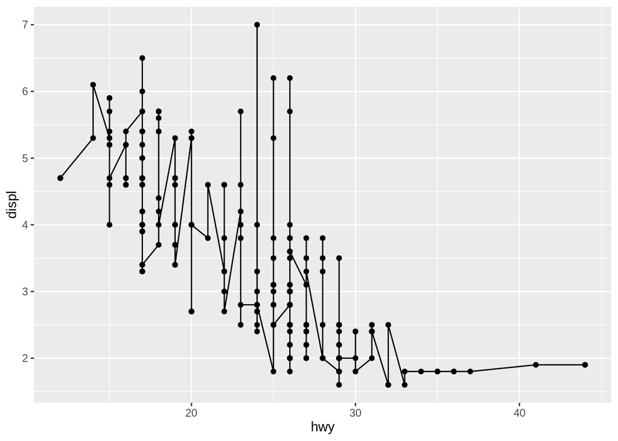

```r
ggplot(mpg, aes(hwy, displ)) +
  geom_point() +
  geom_line()
```

It’s important to be clear about which type of chart you’re expected to produce! I always refer to the prior as a trendline, for clarity.

These types of charts have enormous value for quick exploratory graphics, showing how various combinations of variables interact with one another. For instance, many analysts start familiarizing themselves with new datasets using correlation matrices (also known as scatterplot matrices), which create a grid of scatterplots representing each variable:

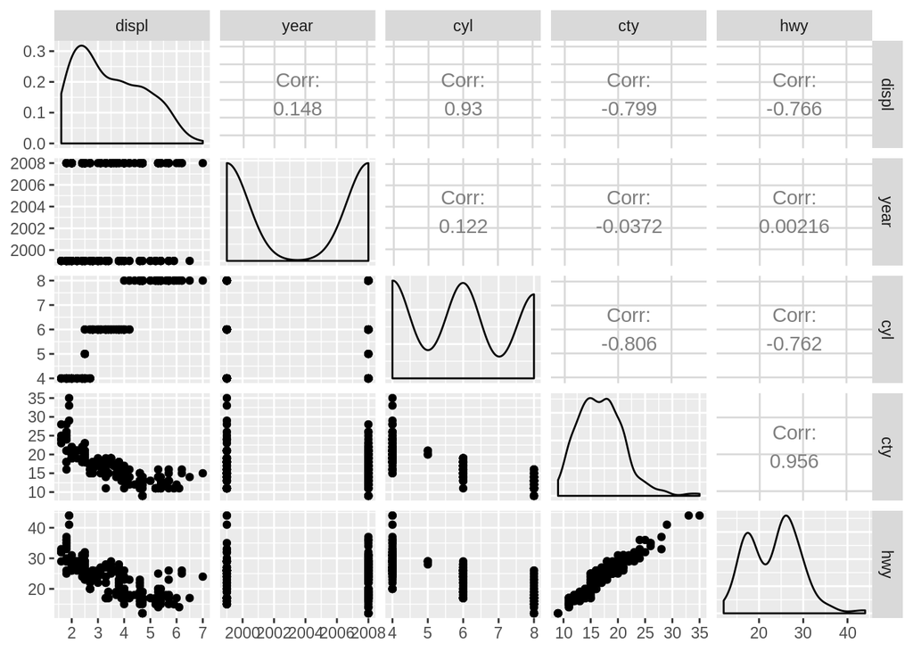

```r
mpg %>%
  select_if(is.numeric) %>%
  GGally::ggpairs()
```

In this format, understanding interactions between your data is quick and easy, with certain variable interactions obviously jumping out as promising avenues for further exploration.

To back up just a little, there’s one major failing of scatterplots that I want to highlight before moving on. If you happen to have more than one point with the same x and y values, a scatterplot will just draw each point over the previous, making it seem like you have less data than you actually do. Adding a little bit of random noise - for instance, using RAND() in Excel - to your values can help show the actual densities of your data, especially when you’re dealing with numbers that haven’t been measured as precisely as they could a have been.

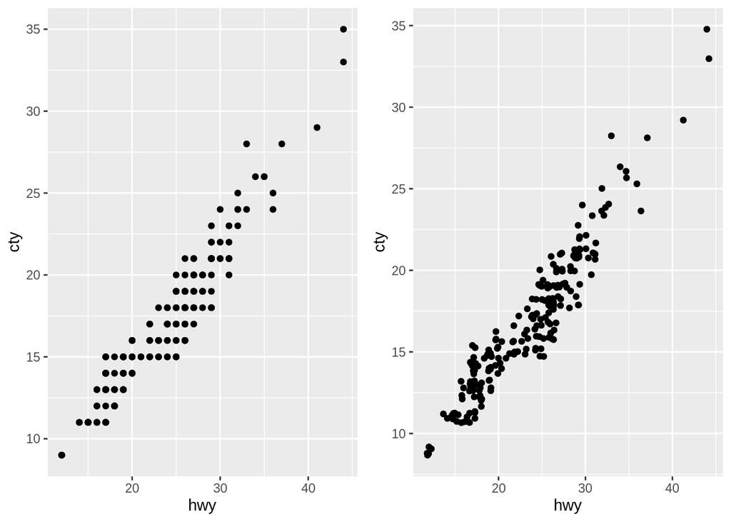

```r
a <- ggplot(mpg, aes(hwy, cty)) +
  geom_point()

b <- ggplot(mpg, aes(hwy, cty)) +
  geom_jitter()

cowplot::plot_grid(a, b)
```

One last chart that does well with two continuous variables is the area chart, which resembles a line chart but fills in the area beneath the line:

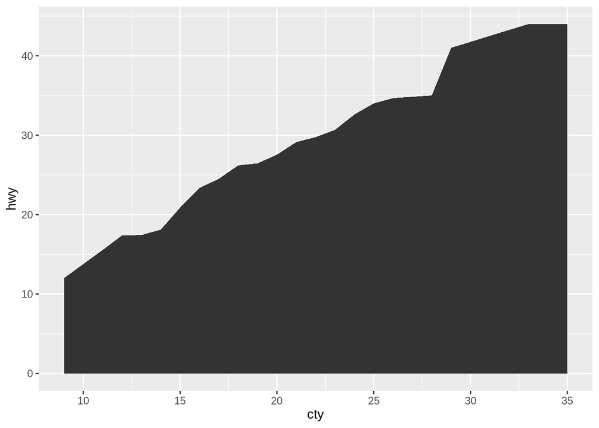

```r
mpg %>%
  group_by(cty) %>%
  summarise(hwy = mean(hwy)) %>%
ggplot(aes(cty, hwy)) +
  geom_area()
```

Area plots make sense when 0 is a relevant number to your dataset – that is, a 0 value wouldn’t be particularly unexpected. They’re also frequently used when you have multiple groupings and care about their total sum:

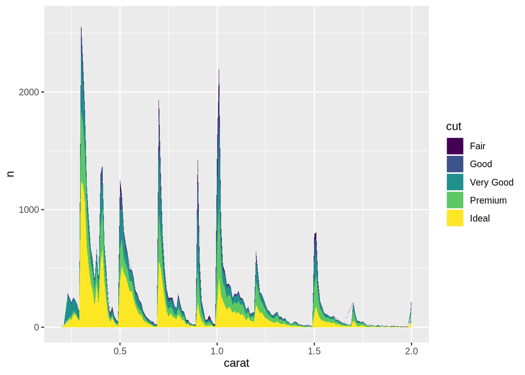

```r
diamonds %>%
  count(carat, cut) %>%
  ggplot(aes(carat, n, fill = cut)) +
  geom_area() +
  scale_x_continuous(limits = c(0.2, 2))
```

(This new dataset is the “diamonds” dataset, representing 54,000 diamonds sizes, qualities, cut, and sale prices. We’ll be going back and forth using it and the EPA dataset from now on.)

Now one drawback of stacked area charts is that it can be very hard to estimate how any individual grouping shifts along the x axis, due to the cumulative effects of all the groups underneath them. For instance, there are actually fewer “fair” diamonds at 0.25 carats than at 1.0 – but because “ideal” and “premium” spike so much, your audience might draw the wrong conclusions. In situations where the total matters more than the groupings, this is alright – but otherwise, it’s worth looking at other types of charts as a result.

### One continuous variable

If instead you’re looking to see how a single continuous variable is distributed throughout your dataset, one of the best tools at your disposal is the histogram. A histogram shows you how many observations in your dataset fall into a certain range of a continuous variable, and plot that count as a barplot:

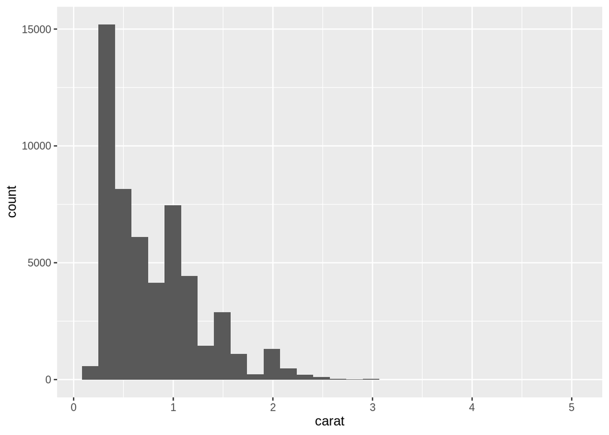

```r
ggplot(diamonds, aes(carat)) +
  geom_histogram()
```

One important flag to raise with histograms is that you need to pay attention to how your data is being binned. If you haven’t picked the right width for your bins, you might risk missing peaks and valleys in your dataset, and might misunderstand how your data is distributed – for instance, look what shifts if we graph 500 bins, instead of the 30 we used above:

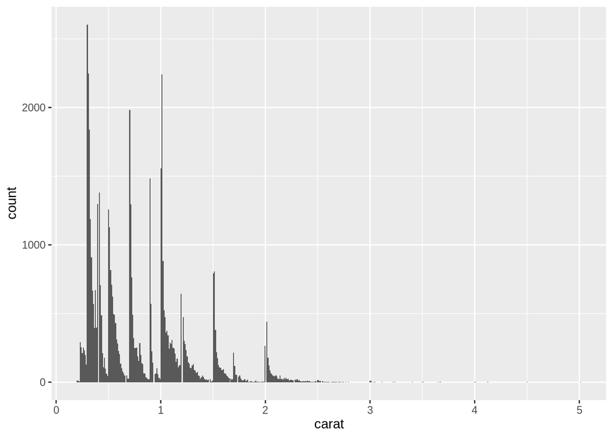

```r
ggplot(diamonds, aes(carat)) +
  geom_histogram(bins = 500)
```

An alternative to the histogram is the frequency plot, which uses a line chart in the place of bars to represent the frequency of a value in your dataset:

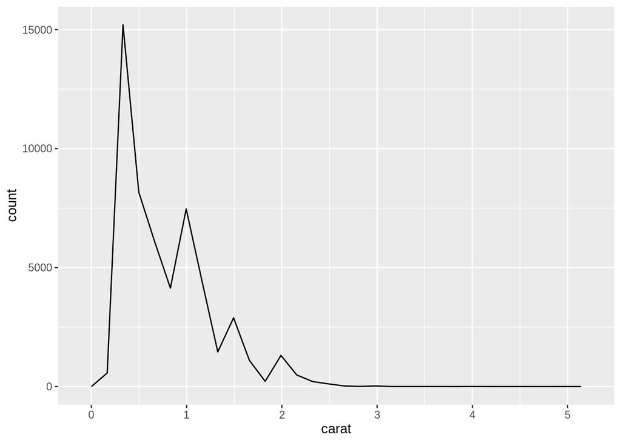

```r
ggplot(diamonds, aes(carat)) +
  geom_freqpoly(bins = 30)
```

Again, however, you have to pay attention to how wide your data bins are with these charts – you might accidentally smooth over major patterns in your data if you aren’t careful!

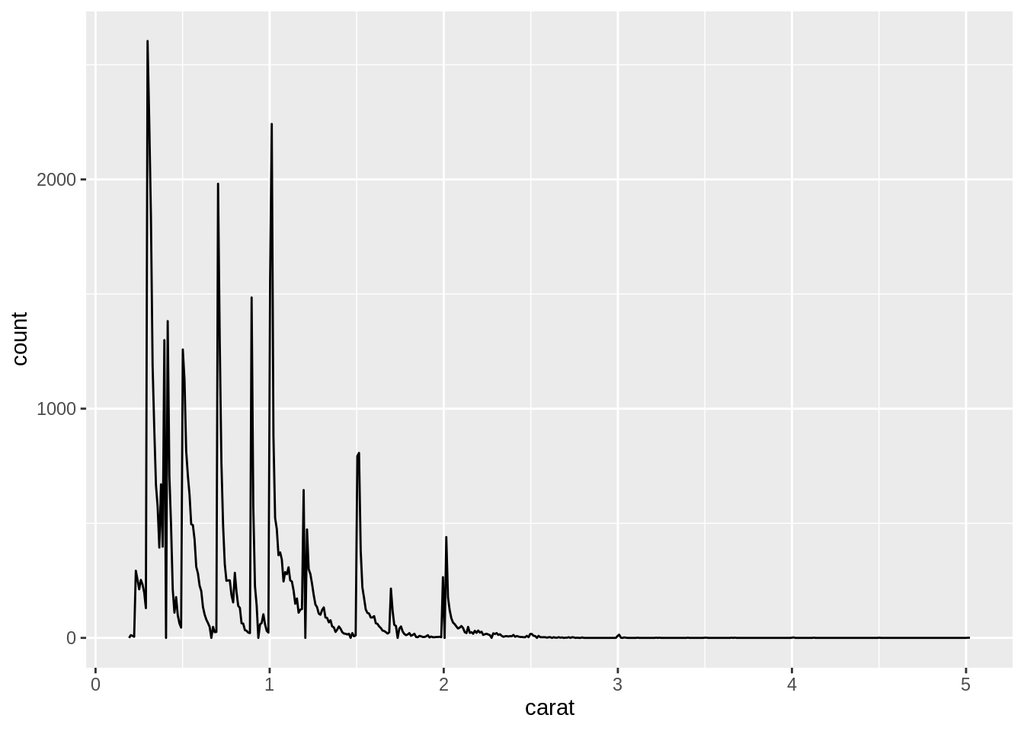

```r
ggplot(diamonds, aes(carat)) +
  geom_freqpoly(bins = 500)
```

One large advantage of the frequency chart over the histogram is how it deals with multiple groupings – if your groupings trade dominance at different levels of your variable, the frequency graph will make it much more obvious how they shift than a histogram will.

(Note that I’ve done something weird to the data in order to show how the distributions change below.)

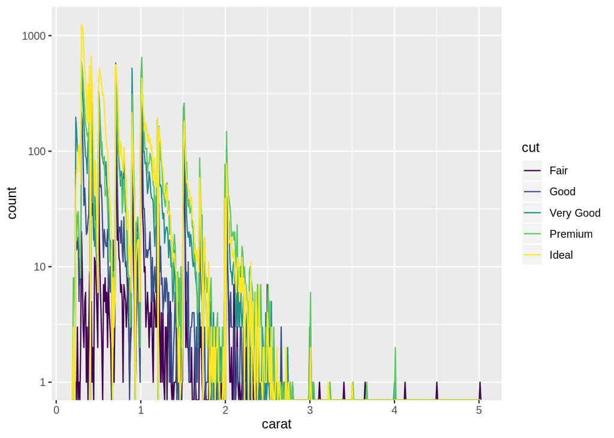

```r
ggplot(diamonds, aes(carat, color = cut)) +
  geom_freqpoly(bins = 500) +
  scale_y_log10()
```

### One categorical variable, one continous

If you want to compare a categorical and continuous variable, you’re usually stuck with some form of bar chart:

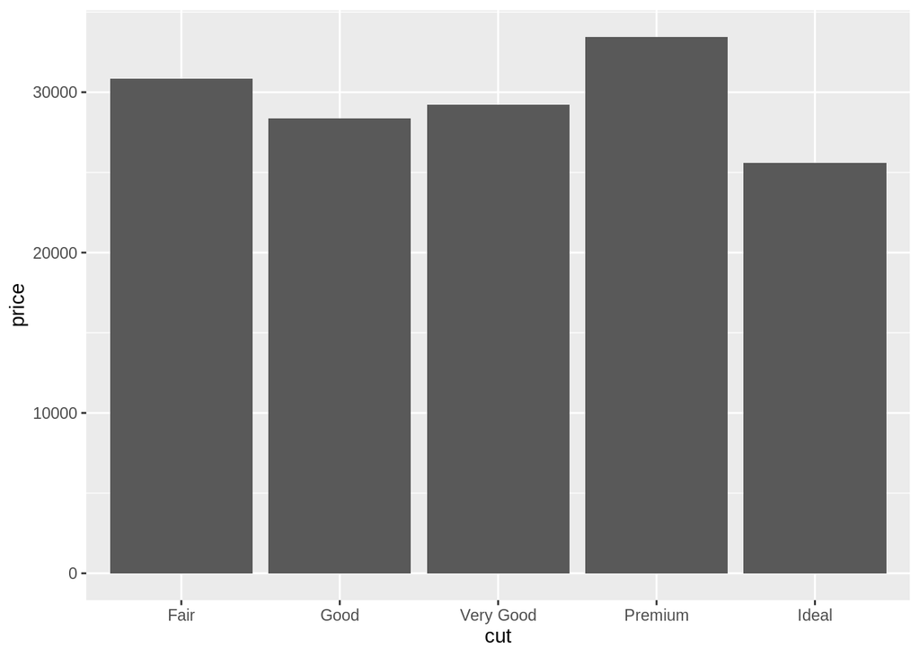

```r
diamonds %>%
  group_by(cut, color) %>%
  summarise(price = mean(price)) %>%
  ggplot(aes(cut, price)) +
  geom_col()
```

The bar chart is possibly the least exciting type of graph in existence, mostly because of how prevalent it is – but that’s because it’s really good at what it does. Bar charts are one of the most easily interpreted and effective types of visualizations, no matter how exciting they are.

However, some people are really intent on ruining that. Take, for instance, the stacked bar chart, often used to add a third variable to the mix:

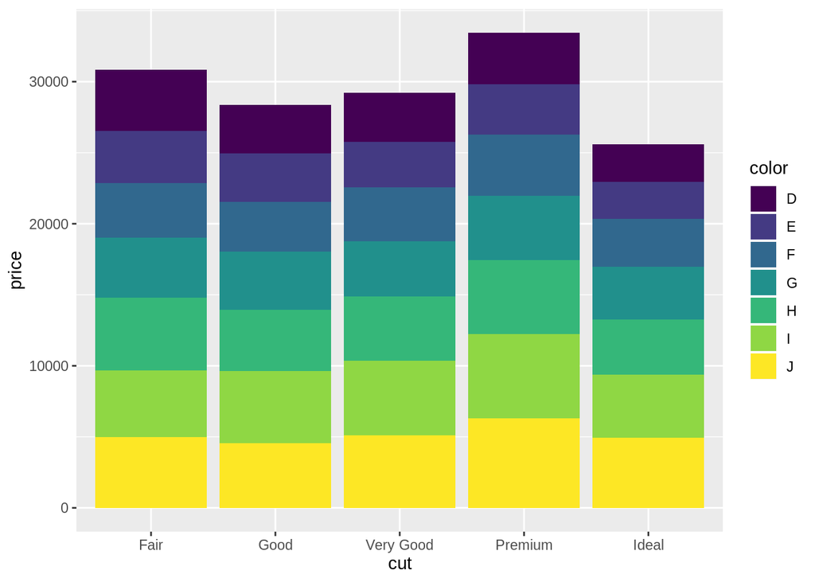

```r
diamonds %>%
  group_by(cut, color) %>%
  summarise(price = mean(price)) %>%
  ggplot(aes(cut, price, fill = color)) +
  geom_col()
```

Compare Fair/G to Premium/G. It’s next to impossible to accurately compare the boxes – they don’t share a top or a bottom line, so you can’t really make a comparison. In these situations, it’s a better idea to use a dodged bar chart instead:

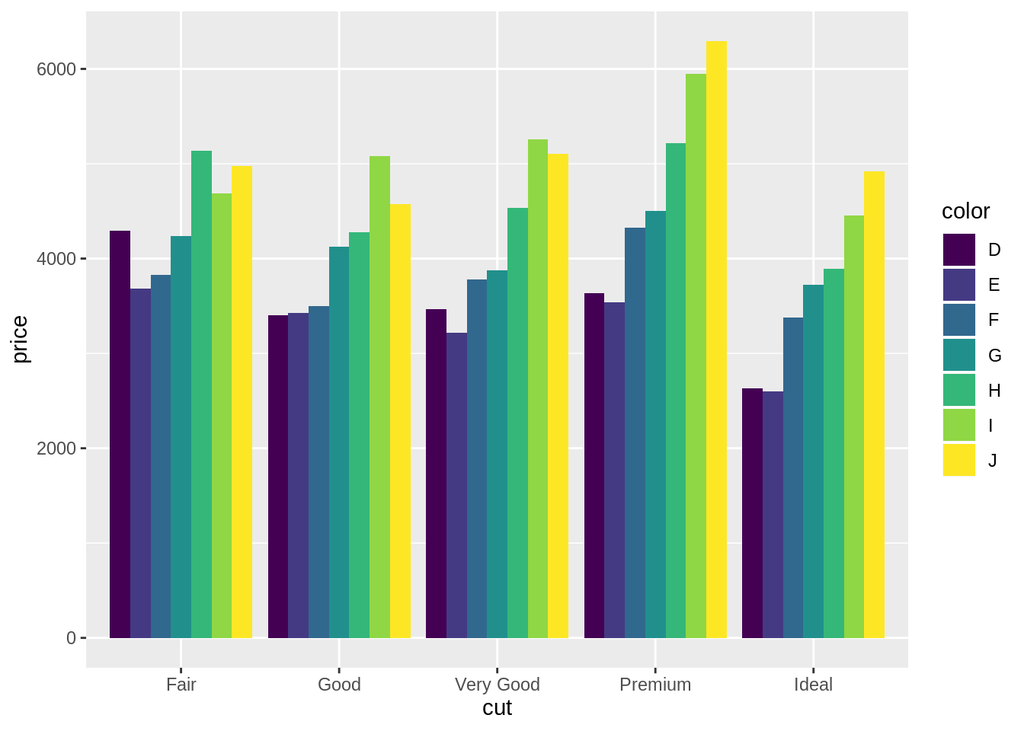

```r
diamonds %>%
  group_by(cut, color) %>%
  summarise(price = mean(price)) %>%
  ggplot(aes(cut, price, fill = color)) +
  geom_col(position = "dodge")
```

Dodged bar charts are usually a better choice for comparing the actual numbers of different groupings. However, this chart does a good job showing one of the limitations dodged bar charts come up against – once you get past 4 or 5 groupings, making comparisons is tricky. In these cases, you’re probably trying to apply the wrong chart for the job, and should consider either breaking your chart up into smaller ones – remember, ink is cheap, and electrons or cheaper – or replacing your bars with a few lines.

The one place where stacked bar charts are appropriate, however, is when you’re comparing the relative proportions of two different groups in each bar. For instance, take the following graph:

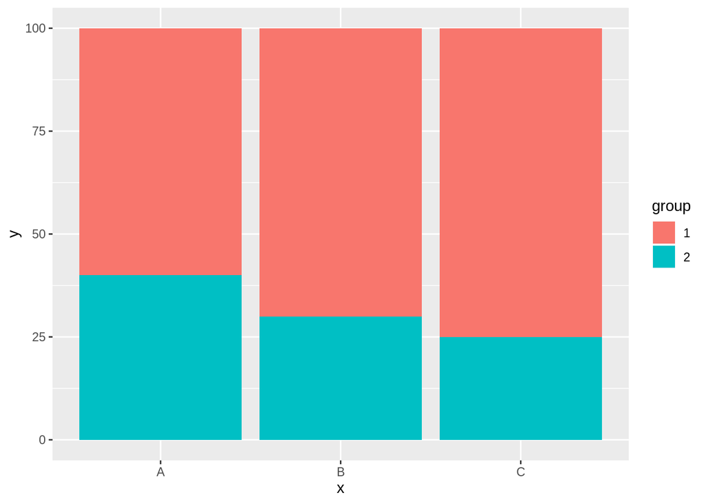

```r
df <- tibble(x = rep(c("A", "B", "C"), each = 2),
             y = c(60, 40, 70, 30, 75, 25),
             group = rep(c("1", "2"), 3))

ggplot(df, aes(x, y, fill = group)) +
  geom_col()
```

In this case, making comparisons across groups is trivial, made simple by the fact that the groupings all share a common line - at 100% for group 1, and at 0% for group 2. This point of reference solves the issue we had with more than two groupings – though note we’d still prefer a dodged bar chart if the bars didn’t always sum to the same amount.

#### A Quick Tangent

This is usually where most people will go on a super long rant about pie charts and how bad they are. They’re wrong, but in an understandable way. People love to hate on pie charts, because they’re almost universally a bad chart. However, if it’s important for your viewer to be able to quickly figure out what proportion two or more groupings make up of the whole, a pie chart is actually the fastest and most effective way to get the point across. For instance, compare the following pie and bar charts, made with the same dataset:

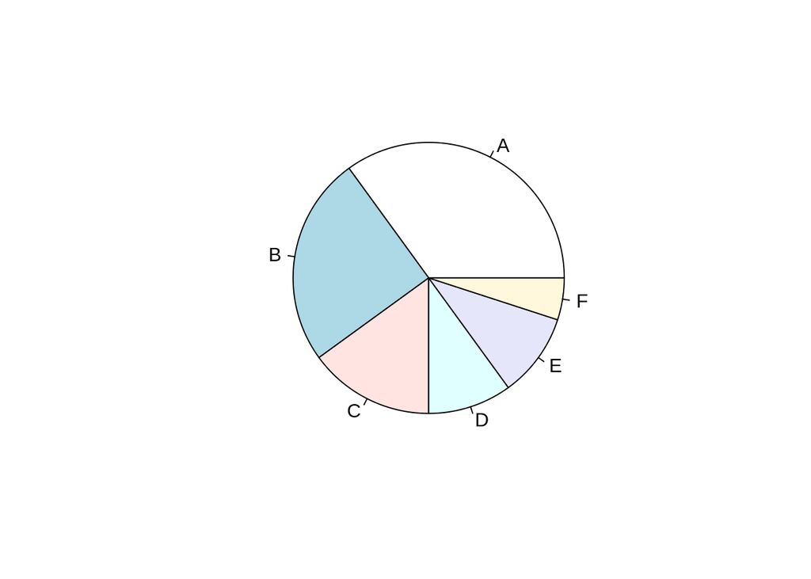

```r
df <- tibble(x = rep(1, 6),
   y = c(0.35, 0.25, 0.15, 0.1, 0.1, 0.05),
   group = c("A", "B", "C", "D", "E", "F"))

pie(df$y, labels = df$group)
```

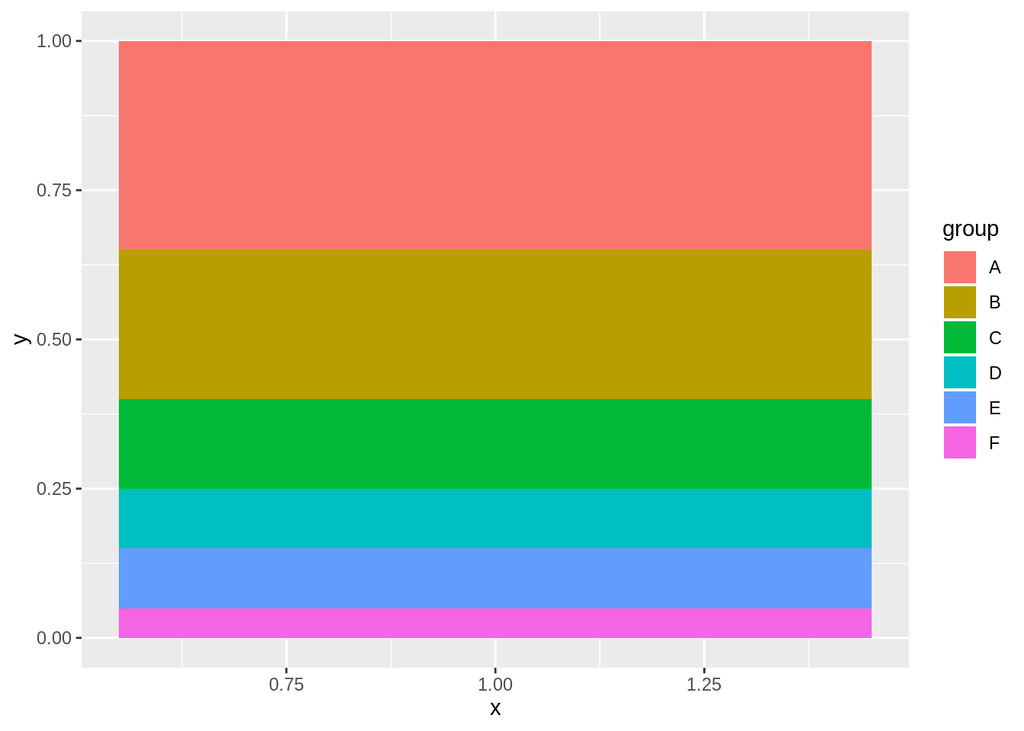

```r
ggplot(df, aes(x, y, fill = group)) +
  geom_col()
```

It’s a lot easier to tell that, say, A is smaller than C through F in the pie chart than the bar plot, since humans are better at summing angles than areas. In these instances, feel free to use a pie chart – and to tell anyone giving you flack that I said it was OK.

### Two categorical variables

Our last combination is when you’re looking to have a categorical variable on both the x and y axis. These are trickier plots to think about, as we no longer encode value in position based on how far away a point is from the lower left hand corner, but rather have to get creative in effectively using position to encode a value. Remember that a geom is a geometric representation of how your dataset is distributed along the x and y axes of your graph. When both of your axes are categorical, you have to get creative to show that distribution.

One method is to use density, as we would in a scatterplot, to show how many datapoints you have falling into each combination of categories graphed. You can do this by making a “point cloud” chart, where more dense clouds represent more common combinations:

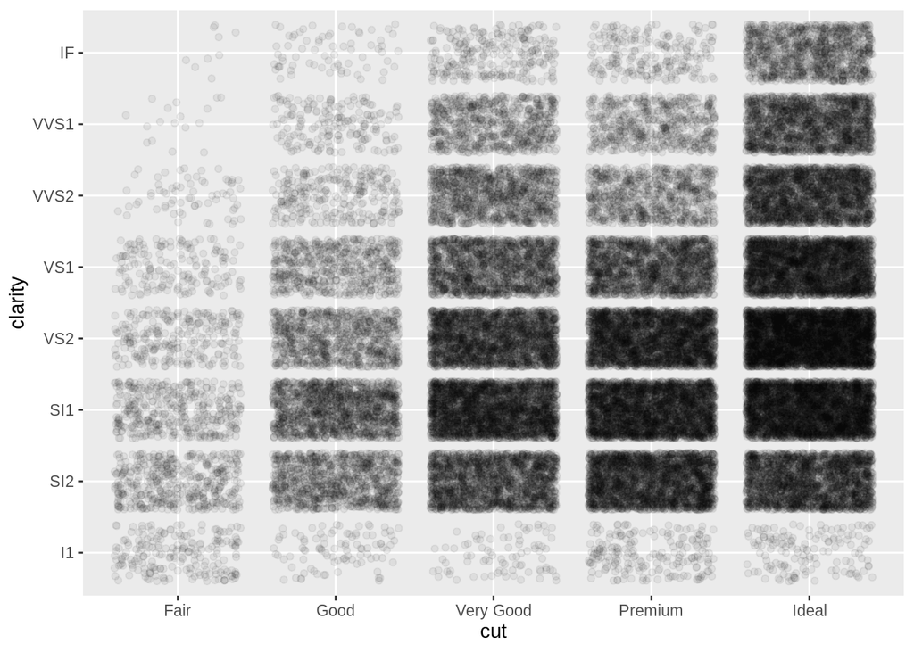

```r
ggplot(diamonds, aes(cut, clarity)) +
  geom_jitter(alpha = 0.06)
```

Even without a single number on this chart, its message is clear - we can tell how our diamonds are distributed with a single glance. A similar way to do this is to use a heatmap, where differently colored cells represent a range of values:

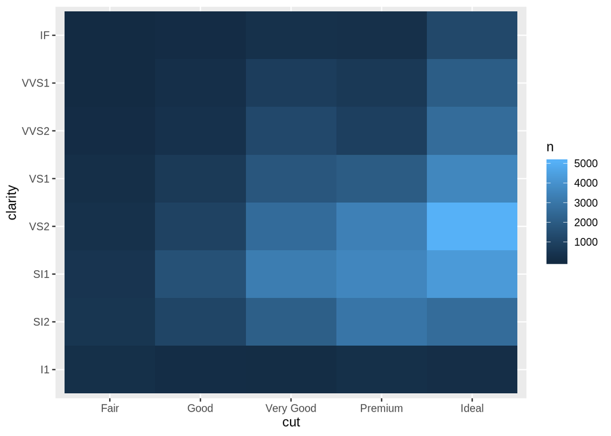

```r
diamonds %>%
  count(cut, clarity) %>%
  ggplot(aes(cut, clarity, fill = n)) +
  geom_tile()
```

I personally think heatmaps are less effective – partially because by using the color aesthetic to encode this value, you can’t use it for anything else – but they’re often easier to make with the resources at hand.